# Assignment_3_Romanus

```python
import numpy as np
import pandas as pd
import matplotlib as mpl
from matplotlib import pyplot as plt
import scipy.stats as st
import scipy.optimize as optimize
import math
```

```python
df = pd.read_csv('https://raw.githubusercontent.com/romanus/data/master/train.csv')
df.head()
```

|  | Id | MSSubClass | MSZoning | LotFrontage | LotArea | Street | Alley | LotShape | LandContour | Utilities | LotConfig | LandSlope | Neighborhood | Condition1 | Condition2 | BldgType | HouseStyle | OverallQual | OverallCond | YearBuilt | YearRemodAdd | RoofStyle | RoofMatl | Exterior1st | Exterior2nd | MasVnrType | MasVnrArea | ExterQual | ExterCond | … |
| --- | --- | --- | --- | --- | --- | --- | --- | --- | --- | --- | --- | --- | --- | --- | --- | --- | --- | --- | --- | --- | --- | --- | --- | --- | --- | --- | --- | --- | --- | --- |
| 0 | 1 | 60 | RL | 65.0 | 8450 | Pave | NaN | Reg | Lvl | AllPub | Inside | Gtl | CollgCr | Norm | Norm | 1Fam | 2Story | 7 | 5 | 2003 | 2003 | Gable | CompShg | VinylSd | VinylSd | BrkFace | 196.0 | Gd | TA | … |
| 1 | 2 | 20 | RL | 80.0 | 9600 | Pave | NaN | Reg | Lvl | AllPub | FR2 | Gtl | Veenker | Feedr | Norm | 1Fam | 1Story | 6 | 8 | 1976 | 1976 | Gable | CompShg | MetalSd | MetalSd | None | 0.0 | TA | TA | … |
| 2 | 3 | 60 | RL | 68.0 | 11250 | Pave | NaN | IR1 | Lvl | AllPub | Inside | Gtl | CollgCr | Norm | Norm | 1Fam | 2Story | 7 | 5 | 2001 | 2002 | Gable | CompShg | VinylSd | VinylSd | BrkFace | 162.0 | Gd | TA | … |
| 3 | 4 | 70 | RL | 60.0 | 9550 | Pave | NaN | IR1 | Lvl | AllPub | Corner | Gtl | Crawfor | Norm | Norm | 1Fam | 2Story | 7 | 5 | 1915 | 1970 | Gable | CompShg | Wd Sdng | Wd Shng | None | 0.0 | TA | TA | … |
| 4 | 5 | 60 | RL | 84.0 | 14260 | Pave | NaN | IR1 | Lvl | AllPub | FR2 | Gtl | NoRidge | Norm | Norm | 1Fam | 2Story | 8 | 5 | 2000 | 2000 | Gable | CompShg | VinylSd | VinylSd | BrkFace | 350.0 | Gd | TA | … |

5 rows × 81 columns

# Problem 5: linear regression

The overall objective is to explain the sale prices by a set of variables using the data set from the previous two assignments.

```python
import statsmodels.api as sm
import statsmodels.formula.api as smf
import statsmodels.imputation as smi
from sklearn.model_selection import cross_val_score
from sklearn.linear_model import LinearRegression
```

## Task 1

Before fitting a model to the data, first we have a closer look at the definitions of the variables and decide if some of them might require a separate treatment. Consider, for example, the first variable $\texttt{MSSubClass}$. It takes textual values and obviously cannot we included into the linear model as it is. There are two possibilities how this can be handled. One approach is to assign numbers from 1 to 16 to each possible outcome. Another approach is to create new dummy variables that are equal to one for a specific outcome and zero else. Discuss these two approaches and suggest which approach is more appropriate. Motivate your decision and keep in mind the nominal, ordinal, and cardinal scalings from Statistics. Run a simple regression of $\texttt{SalePrices}$ on $\texttt{MSSubClass}$ taken as it is (without creating dummies or 1,...,16 variable). Check how does your software handle this type of a variable. (In R your data set must be stored as a data frame.)

```python
print(df['MSSubClass'].unique())
print(df['MSSubClass'].dtype)
```

```
[ 60  20  70  50 190  45  90 120  30  85  80 160  75 180  40]
int64
```

Summarizing, we cannot assign numbers from 1 to 16, but we can create dummy variables.

Let's run the regression on this feature:

```python
X = df['MSSubClass']
X = sm.add_constant(X)
y = df['SalePrice']
model = sm.OLS(y, X).fit()
print("R^2:", model.rsquared)
print("Intercept:", model.params.const)
```

```
R^2: 0.007103815434038263
Intercept: 189927.44339978375
```

It looks like the model explains almost nothing.

## Task 2

Consider the following numeric explanatory variables $\texttt{LotFrontage}$, $\texttt{LotArea}$, $\texttt{YearBuilt}$, $\texttt{BsmtFinSF1}$, $\texttt{BsmtUnfSF}$. Plot the scatter plot of $\texttt{SalePrices}$ vs. these variables.

Analyse every plot and discuss the potential problems / transformations / extentions of the model to take the patterns into account. Remember, that you can either transform variables or create new variables to capture non-standard patterns.

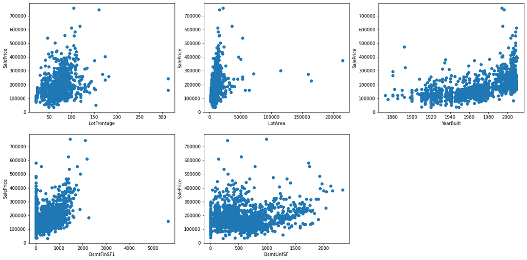

```python
plt.figure(figsize=(20, 10))
plt.subplot(231, xlabel="LotFrontage", ylabel="SalePrice")
plt.scatter('LotFrontage', 'SalePrice', data=df)
plt.subplot(232, xlabel="LotArea", ylabel="SalePrice")
plt.scatter('LotArea', 'SalePrice', data=df)
plt.subplot(233, xlabel="YearBuilt", ylabel="SalePrice")
plt.scatter('YearBuilt', 'SalePrice', data=df)
plt.subplot(234, xlabel="BsmtFinSF1", ylabel="SalePrice")
plt.scatter('BsmtFinSF1', 'SalePrice', data=df)
plt.subplot(235, xlabel="BsmtUnfSF", ylabel="SalePrice")
plt.scatter('BsmtUnfSF', 'SalePrice', data=df)
plt.show()
```

Observations:

- Some plots have extreme outliers ($\texttt{LotFrontage}$, $\texttt{LotArea}$ and $\texttt{BsmtFinSF1}$). This will affect the errors when doing regressions.
- The $\texttt{LotArea}$ plot is going to have a very high slope with respect to other feature, because the regression line is going to be almost vertical.
- The $\texttt{YearBuild}$ plot shows some nonlinear dependency. Probably, we should give a look at the $\texttt{SalePrice} \sim \texttt{YearBuild}^n$ dependency with $n \in [1.5, 2]$.
- The $\texttt{BsmtFinSF1}$ and plot has many values with $x = 0$. This may affect the model as well. One of the possible workarounds might be creating a dummy variable with ones where $\texttt{BsmtFinSF1} \ne 0$ and estimate such model. The same idea applies to $\texttt{BsmtUnfSF}$.

## Task 3

Fit a simple linear regression without making the transformations discussed above.

Pick up one of the numeric regressors, for example, LotArea. Write down the corresponding hypothesis of the $t$-test. Provide the formula for the test statistics, explain the components of the formula and give the values for these components. Assess the goodness-of-fit of the model. Explain in your own words the difference between $R^2$ and adjusted $R^2$.

```python
for key in ['LotFrontage', 'LotArea', 'YearBuilt', 'BsmtFinSF1', 'BsmtUnfSF']:
  print(key, 'contains nans:', df[key].isnull().values.any())
```

```
LotFrontage contains nans: True
LotArea contains nans: False
YearBuilt contains nans: False
BsmtFinSF1 contains nans: False
BsmtUnfSF contains nans: False
```

```python
not_nans = df['LotFrontage'].notnull().values
X = df[['LotFrontage', 'LotArea', 'YearBuilt', 'BsmtFinSF1', 'BsmtUnfSF']][not_nans]
X = sm.add_constant(X)
y = df['SalePrice'][not_nans]
model = sm.OLS(y, X).fit(use_t=True)
print(model.summary())
```

```
                            OLS Regression Results
==============================================================================
Dep. Variable:              SalePrice   R-squared:                       0.518
Model:                            OLS   Adj. R-squared:                  0.516
Method:                 Least Squares   F-statistic:                     256.6
Date:                Sun, 29 Nov 2020   Prob (F-statistic):          2.43e-186
Time:                        19:05:15   Log-Likelihood:                -14875.
No. Observations:                1201   AIC:                         2.976e+04
Df Residuals:                    1195   BIC:                         2.979e+04
Df Model:                           5
Covariance Type:            nonrobust
===============================================================================
                  coef    std err          t      P>|t|      [0.025      0.975]
-------------------------------------------------------------------------------
const        -1.74e+06   1.14e+05    -15.302      0.000   -1.96e+06   -1.52e+06
LotFrontage   344.6230     79.756      4.321      0.000     188.145     501.101
LotArea         1.5064      0.237      6.350      0.000       1.041       1.972
YearBuilt     918.7825     58.450     15.719      0.000     804.107    1033.458
BsmtFinSF1     77.2888      4.860     15.902      0.000      67.753      86.824
BsmtUnfSF      65.4157      4.800     13.627      0.000      55.998      74.834
==============================================================================
Omnibus:                      360.517   Durbin-Watson:                   2.001
Prob(Omnibus):                  0.000   Jarque-Bera (JB):            15364.860
Skew:                           0.629   Prob(JB):                         0.00
Kurtosis:                      20.477   Cond. No.                     8.71e+05
==============================================================================

Warnings:
[1] Standard Errors assume that the covariance matrix of the errors is correctly specified.
[2] The condition number is large, 8.71e+05. This might indicate that there are
strong multicollinearity or other numerical problems.
```

The hypothesis for the $t$-test:

$\begin{cases} H_0: \beta_{LotArea} = 0, \text{ (}\texttt{LotArea}\text{ has no impact on the model)} \\ H_1: \beta_{LotArea} \ne 0 \end{cases}$

The corresponding $t$-static:

$t_{emp} = \frac{\widehat{\beta_{LotArea}} - \beta_{LotArea}}{\sqrt{\widehat{Var(\beta_{LotArea})}}} \sim t_{N-K-1}$,

where N is the sample size, K is the number of model coefficients.

We are going to pick the $t$-statistic and the $p$-value from the software:

```python
print("LotArea:")
print("t-statistic =", model.tvalues['LotArea'])
print("p-value =", model.pvalues['LotArea'])
```

```
LotArea:
t-statistic = 6.350087041152089
p-value = 3.051053509926743e-10
```

So, we can reject $H_0$ with any reasonable confidence level. This means that $\texttt{LotArea}$ is significant to computing $\texttt{SalePrice}$.

Let's compute some goodness-of-fit measures:

```python
print("R^2:", model.rsquared)
print("R^2 adj:", model.rsquared_adj)
```

```
R^2: 0.517719655058728
R^2 adj: 0.5157017456656683
```

Both $R^2$s show that we explain the model relatively good. The difference between $R^2$ and $R^2_{adj}$ is that $R^2$ grows as the number of parameters increase, while $R^2_{adj}$ doesn't.

## Task 4

If you wish to argue that $\texttt{MSSubClass}$ is insignificant and use the model with dummies than you have to check the simultaneous insignificance of all the dummies that stem from the factor variable $\texttt{MSSubClass}$. Run a test for a general linear hypothesis and conclude about the significance of the general MSSubClass. Provide the matrix and the vector needed in the hypothesis.

```python
model = smf.ols(formula='SalePrice ~ C(MSSubClass) + LotFrontage + LotArea + YearBuilt + BsmtFinSF1 + BsmtUnfSF', data=df).fit(use_t=True)
print(model.summary())
```

```
                            OLS Regression Results
==============================================================================
Dep. Variable:              SalePrice   R-squared:                       0.616
Model:                            OLS   Adj. R-squared:                  0.610
Method:                 Least Squares   F-statistic:                     99.90
Date:                Sun, 29 Nov 2020   Prob (F-statistic):          9.42e-230
Time:                        19:05:15   Log-Likelihood:                -14737.
No. Observations:                1201   AIC:                         2.951e+04
Df Residuals:                    1181   BIC:                         2.962e+04
Df Model:                          19
Covariance Type:            nonrobust
========================================================================================
                           coef    std err          t      P>|t|      [0.025      0.975]
----------------------------------------------------------------------------------------
Intercept            -2.056e+06   1.82e+05    -11.301      0.000   -2.41e+06    -1.7e+06
C(MSSubClass)[T.30]   9386.4240   8448.396      1.111      0.267   -7189.115     2.6e+04
C(MSSubClass)[T.40]   1.502e+04   3.05e+04      0.493      0.622   -4.48e+04    7.48e+04
C(MSSubClass)[T.45]   1.426e+04   1.58e+04      0.901      0.368   -1.68e+04    4.53e+04
C(MSSubClass)[T.50]   3.592e+04   6539.446      5.494      0.000    2.31e+04    4.88e+04
C(MSSubClass)[T.60]   5.355e+04   4690.097     11.418      0.000    4.43e+04    6.28e+04
C(MSSubClass)[T.70]   8.228e+04   9214.299      8.930      0.000    6.42e+04       1e+05
C(MSSubClass)[T.75]   1.018e+05   1.49e+04      6.826      0.000    7.26e+04    1.31e+05
C(MSSubClass)[T.80]   1.422e+04   8951.972      1.589      0.112   -3340.435    3.18e+04
C(MSSubClass)[T.85]  -7942.8466   1.43e+04     -0.556      0.578    -3.6e+04    2.01e+04
C(MSSubClass)[T.90]  -1.562e+04   8091.886     -1.930      0.054   -3.15e+04     256.938
C(MSSubClass)[T.120]  2918.6544   7526.709      0.388      0.698   -1.18e+04    1.77e+04
C(MSSubClass)[T.160]  3511.3769   8480.096      0.414      0.679   -1.31e+04    2.01e+04
C(MSSubClass)[T.180] -1.577e+04   1.73e+04     -0.914      0.361   -4.96e+04    1.81e+04
C(MSSubClass)[T.190]  2.588e+04   1.13e+04      2.293      0.022    3736.302     4.8e+04
LotFrontage            170.9204     83.191      2.055      0.040       7.701     334.140
LotArea                  1.2422      0.214      5.798      0.000       0.822       1.663
YearBuilt             1072.4061     92.723     11.566      0.000     890.486    1254.327
BsmtFinSF1              89.2394      4.646     19.209      0.000      80.124      98.354
BsmtUnfSF               69.8095      4.724     14.779      0.000      60.542      79.077
==============================================================================
Omnibus:                      365.924   Durbin-Watson:                   2.005
Prob(Omnibus):                  0.000   Jarque-Bera (JB):            43348.527
Skew:                          -0.195   Prob(JB):                         0.00
Kurtosis:                      32.430   Cond. No.                     1.56e+06
==============================================================================

Warnings:
[1] Standard Errors assume that the covariance matrix of the errors is correctly specified.
[2] The condition number is large, 1.56e+06. This might indicate that there are
strong multicollinearity or other numerical problems.
```

We are going to run a general linear hypothesis now. In the software we are currently using, there is an f_test function which does exactly that. The null hypothesis:

$H_0: R\beta = 0$

```python
# the first feature is Intercept, the 14 next are the dummy variables
R = np.eye(15, 20)[1:]
r = np.zeros((14,))
print(R)
```

```
[[0. 1. 0. 0. 0. 0. 0. 0. 0. 0. 0. 0. 0. 0. 0. 0. 0. 0. 0. 0.]
 [0. 0. 1. 0. 0. 0. 0. 0. 0. 0. 0. 0. 0. 0. 0. 0. 0. 0. 0. 0.]
 [0. 0. 0. 1. 0. 0. 0. 0. 0. 0. 0. 0. 0. 0. 0. 0. 0. 0. 0. 0.]
 [0. 0. 0. 0. 1. 0. 0. 0. 0. 0. 0. 0. 0. 0. 0. 0. 0. 0. 0. 0.]
 [0. 0. 0. 0. 0. 1. 0. 0. 0. 0. 0. 0. 0. 0. 0. 0. 0. 0. 0. 0.]
 [0. 0. 0. 0. 0. 0. 1. 0. 0. 0. 0. 0. 0. 0. 0. 0. 0. 0. 0. 0.]
 [0. 0. 0. 0. 0. 0. 0. 1. 0. 0. 0. 0. 0. 0. 0. 0. 0. 0. 0. 0.]
 [0. 0. 0. 0. 0. 0. 0. 0. 1. 0. 0. 0. 0. 0. 0. 0. 0. 0. 0. 0.]
 [0. 0. 0. 0. 0. 0. 0. 0. 0. 1. 0. 0. 0. 0. 0. 0. 0. 0. 0. 0.]
 [0. 0. 0. 0. 0. 0. 0. 0. 0. 0. 1. 0. 0. 0. 0. 0. 0. 0. 0. 0.]
 [0. 0. 0. 0. 0. 0. 0. 0. 0. 0. 0. 1. 0. 0. 0. 0. 0. 0. 0. 0.]
 [0. 0. 0. 0. 0. 0. 0. 0. 0. 0. 0. 0. 1. 0. 0. 0. 0. 0. 0. 0.]
 [0. 0. 0. 0. 0. 0. 0. 0. 0. 0. 0. 0. 0. 1. 0. 0. 0. 0. 0. 0.]
 [0. 0. 0. 0. 0. 0. 0. 0. 0. 0. 0. 0. 0. 0. 1. 0. 0. 0. 0. 0.]]
```

```python
model.f_test((R,r))
```

```
<class 'statsmodels.stats.contrast.ContrastResults'>
<F test: F=array([[21.71414893]]), p=8.491982396637465e-50, df_denom=1.18e+03, df_num=14>
```

So, we can reject $H_0$. It appears that $\texttt{MSSubClass}$ has some impact on $\texttt{SalePrice}$.

## Task 5

Provide an economic interpretation for the parameters of $\texttt{LotArea}$, first dummy for $\texttt{MSSubClass}$ (it is a tricky question!), and $\texttt{BedroomAbvGr}$. (Ignore the potential insignificance.) How would the interpretations change if you model log of $\texttt{SalePrice}$?

1. $\texttt{LotArea}$: Lot size in square feet

$\beta_{LogArea}$ is the change of the house price when the lot area increases by 1 square feet.

1. $\texttt{MSSubClass}$: Identifies the type of dwelling involved in the sale.

1. $\texttt{BedroomAbvGr}$: Bedrooms above grade

$\beta_{BedroomAbvGr}$ is the change of the house price when the above-grade bedrooms count increases by 1.

1. Regarding $log(\texttt{SalePrice})$: everything is the same but it's a relative change. For example, $\beta_{LogArea}$ now is the percentage change of $\texttt{LogArea}$ when the lot area increases by 1 square feet.

## Task 6

Compute the 95% confidence interval for the parameter of $\texttt{LotArea}$ and provide its economic meaning. Relate the CIs to the tests of significance, i.e. how would you use these intervals to decide about the significance of the corresponding explanatory variables? The CIs are computed relying on the assumption, that the residuals follow normal distribution. Is this assumption fulfilled? Run an appropriate goodness-of-fit test.

Since our parameter follows the $t$-distribution, the 95% CI ($\alpha=0.05$) can be computed as:

$H_0: \beta_{LotArea}^* = 0$

$CI_{1-\alpha/2} = \beta_{LotArea}^* + t_{N-K-1, 1-\alpha/2} \sqrt{\widehat{Var(\beta_{LotArea})}} $

$CI_{\alpha/2} = \beta_{LotArea}^* - t_{N-K-1, 1-\alpha/2} \sqrt{\widehat{Var(\beta_{LotArea})}} $

```python
t_dist = st.t.pdf(0.975, df=int(model.df_resid - model.df_model - 1))
std_estimated = model.bse['LotArea']
CI_high = t_dist * std_estimated
CI_low = -t_dist * std_estimated
print("CI low:", CI_low)
print("CI high:", CI_high)
print("Estimated parameter value:", model.params['LotArea'])
```

```
CI low: -0.053116418536800734
CI high: 0.053116418536800734
Estimated parameter value: 1.2422242322802934
```

Now let's test the data normality with the Kolmogorov-Smirnov test:

$H_0: RSS \sim N(\mu, \sigma^2)$

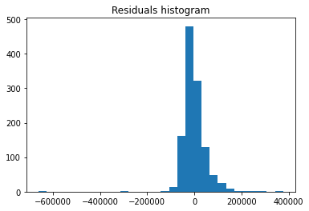

```python
plt.title("Residuals histogram")
plt.hist(model.resid, bins=30)
plt.show()
```

```python
residuals = model.resid
st.kstest((residuals - np.mean(residuals)) / np.std(residuals), 'norm')
```

```
KstestResult(statistic=0.11834238214344561, pvalue=4.110973689783815e-15)
```

$p$-value is very small, so we can reject $H_0$. The data doesn't come from the normal distribution.

## Task 7

Most of the variables appear to be insignificant and we should find the smallest model that still has a good explanatory power. Choose this model using stepwise model selection (either based on the tests for $R^2$ or using $R^2_{adj}$/$AIC$/$BIC$). Pick up the last step of the model selection procedure and explain in details how the method/approach works (or is implemented in your software). Work with this model in all the remaining steps.

```python
# adapted from https://datascience.stackexchange.com/a/24447
def stepwise_selection(X, y, initial_list=[], alpha = 0.05, verbose=True):
    included = list(initial_list)
    while True:
        changed=False

        model = sm.OLS(y, sm.add_constant(pd.DataFrame(X[included]))).fit()

        # backward step
        pvalues = pd.Series(dtype=np.float64)
        rsquareds = pd.Series(dtype=np.float64)

        # use all coefs except intercept
        for col in model.params.index[1:]:
          included_reduced = filter(lambda key: key != col, included)
          model_reduced = sm.OLS(y, sm.add_constant(pd.DataFrame(X[included_reduced]))).fit()
          model_reduced_df = model_reduced.df_model
          fvalue = (model_reduced.df_resid - model_reduced_df) * (model.rsquared - model_reduced.rsquared) / (1 - model.rsquared)
          rsquareds[col] = model_reduced.rsquared
          pvalues[col] = 1 - st.f.cdf(fvalue, 1, model_reduced_df)

        worst_feature = pvalues.index[pvalues.argmax()]
        if pvalues[worst_feature] > alpha:
            changed=True
            included.remove(worst_feature)
            if verbose:
                print('Drop {:20} with p-value {:>12.6}; the updated R^2: {:>.6}'.format(worst_feature, pvalues[worst_feature], rsquareds[worst_feature]))
        if not changed:
            break
    return included
```

```python
df_numeric = df.select_dtypes(include=np.number).dropna()
print("The max model contains", len(df_numeric.columns), "columns")
print("Dropped", len(df)-len(df_numeric), "rows with null entries. The remaining dataframe contains", len(df_numeric), "rows.")
```

```
The max model contains 38 columns
Dropped 339 rows with null entries. The remaining dataframe contains 1121 rows.
```

```python
stepwise_result = stepwise_selection(df_numeric, df_numeric['SalePrice'], initial_list=df_numeric.columns[:-1])

print("The remaining columns count:", len(stepwise_result))
```

```
Drop BsmtFinSF1           with p-value          1.0; the updated R^2: 0.809556
Drop 1stFlrSF             with p-value          1.0; the updated R^2: 0.809556
Drop 2ndFlrSF             with p-value     0.924479; the updated R^2: 0.809554
Drop OpenPorchSF          with p-value     0.914569; the updated R^2: 0.809552
Drop YrSold               with p-value     0.779065; the updated R^2: 0.809538
Drop HalfBath             with p-value     0.742887; the updated R^2: 0.809518
Drop EnclosedPorch        with p-value     0.709899; the updated R^2: 0.809493
Drop LowQualFinSF         with p-value     0.656671; the updated R^2: 0.809456
Drop Id                   with p-value      0.66934; the updated R^2: 0.809423
Drop BsmtHalfBath         with p-value     0.620484; the updated R^2: 0.809378
Drop MoSold               with p-value     0.630149; the updated R^2: 0.809336
Drop MiscVal              with p-value     0.590067; the updated R^2: 0.809283
Drop GarageArea           with p-value     0.596251; the updated R^2: 0.809231
Drop GarageYrBlt          with p-value     0.615592; the updated R^2: 0.809185
Drop 3SsnPorch            with p-value     0.390646; the updated R^2: 0.809049
Drop BsmtFinSF2           with p-value     0.231898; the updated R^2: 0.808781
Drop YearRemodAdd         with p-value      0.21234; the updated R^2: 0.808487
Drop LotFrontage          with p-value    0.0967433; the updated R^2: 0.807947
Drop Fireplaces           with p-value    0.0808261; the updated R^2: 0.80734
Drop FullBath             with p-value    0.0624861; the updated R^2: 0.806635
The remaining columns count: 17
```

```python
new_columns = np.append(stepwise_result, 'SalePrice')
df_new = df_numeric[new_columns]
print(df_new.shape)
df_new.head()
```

```
(1121, 18)
```

|  | MSSubClass | LotArea | OverallQual | OverallCond | YearBuilt | MasVnrArea | BsmtUnfSF | TotalBsmtSF | GrLivArea | BsmtFullBath | BedroomAbvGr | KitchenAbvGr | TotRmsAbvGrd | GarageCars | WoodDeckSF | ScreenPorch | PoolArea | SalePrice |
| --- | --- | --- | --- | --- | --- | --- | --- | --- | --- | --- | --- | --- | --- | --- | --- | --- | --- | --- |
| 0 | 60 | 8450 | 7 | 5 | 2003 | 196.0 | 150 | 856 | 1710 | 1 | 3 | 1 | 8 | 2 | 0 | 0 | 0 | 208500 |
| 1 | 20 | 9600 | 6 | 8 | 1976 | 0.0 | 284 | 1262 | 1262 | 0 | 3 | 1 | 6 | 2 | 298 | 0 | 0 | 181500 |
| 2 | 60 | 11250 | 7 | 5 | 2001 | 162.0 | 434 | 920 | 1786 | 1 | 3 | 1 | 6 | 2 | 0 | 0 | 0 | 223500 |
| 3 | 70 | 9550 | 7 | 5 | 1915 | 0.0 | 540 | 756 | 1717 | 1 | 3 | 1 | 7 | 3 | 0 | 0 | 0 | 140000 |
| 4 | 60 | 14260 | 8 | 5 | 2000 | 350.0 | 490 | 1145 | 2198 | 1 | 4 | 1 | 9 | 3 | 192 | 0 | 0 | 250000 |

**Explanation**

Here we test all nested models using the $F$-test statistics:

$\begin{cases} H_0: R_{M_{out}}^2 = R_M^2 \text{ (both models are equivalent) } \\ H_1: R_{M_{out}}^2 < R_M^2 \text{ (model }M_{out}\text{ is worse) }\end{cases}$

$F-to-remove = \frac{R_M^2 - R_{M_{out}}^2}{1 - R_M^2} \sim F_{1;N-K_1}$

So, for each feature of the dataset we test if removing this feature from the model makes the model statistically different. Then we take the feature with worst $p$-value, for which we still cannot reject $H_0$ and drop it.

At the last iteration removing any of the features would reject $H_0$ and our model would become statistically different $\implies$ the model is selected.

## Task 8

Sometimes data contains outliers which induces bias in the parameter estimates. Check for outliers using plots of the residuals, Cook's distance and leverage. Have a closer look at the observation with the highest leverage (regardless if it is classified as an outlier or not). What makes this observation so outstanding (you may have a look at Box-plots for interval scaled variables or at the frequencies for binary/ordinal variables)?

```python
X = df_new.drop('SalePrice', axis=1)
y = df_new['SalePrice']
model = sm.OLS(y, sm.add_constant(X)).fit()
```

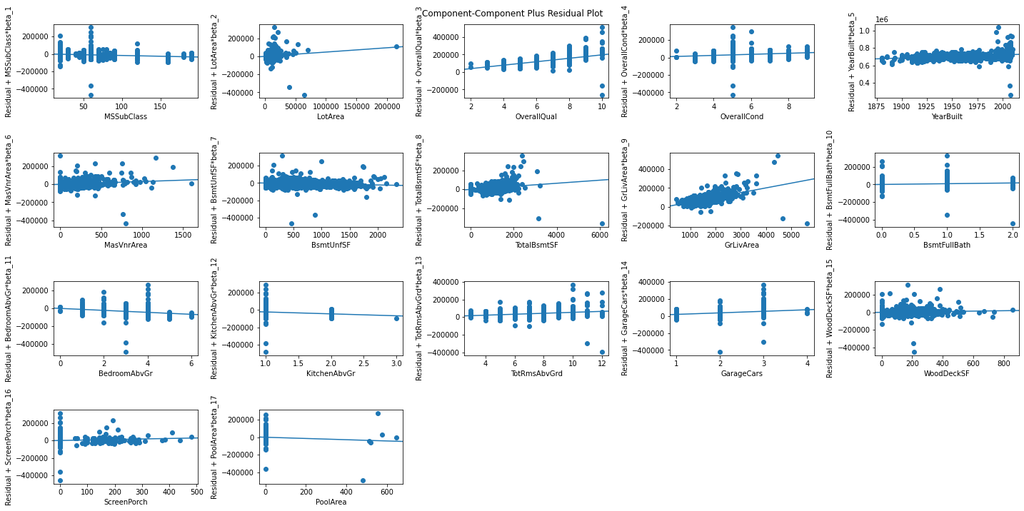

```python
with mpl.rc_context():
  mpl.rc("figure", figsize=(20,10))
  fig = sm.graphics.plot_ccpr_grid(model, grid=(4,5))
  fig.tight_layout(pad=1.0)
```

We can see that there are many outliers. For example, in $\texttt{TotalBsmtSF}$ there is a point with the value of 6000+ which greatly influences the model. For $\texttt{PoolArea}$, we can see the very poor fit.

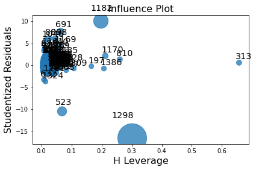

```python
fig = sm.graphics.influence_plot(model, criterion="cooks")
fig.tight_layout(pad=1.0)
```

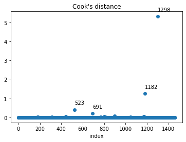

```python
cooks, _ = model.get_influence().cooks_distance
xs = df_new.index
plt.scatter(xs, cooks)
plt.title("Cook's distance")
plt.xlabel("index")
for i, x in enumerate(xs):
  cook = cooks[i]
  if cook > 0.1:
    plt.annotate(x, (x, cook), textcoords="offset points", xytext=(0,10))
plt.show()
```

We need to inspect the point 313, which has a leverage of ~0.65.

```python
df_new[df_new.index == 313]
```

|  | MSSubClass | LotArea | OverallQual | OverallCond | YearBuilt | MasVnrArea | BsmtUnfSF | TotalBsmtSF | GrLivArea | BsmtFullBath | BedroomAbvGr | KitchenAbvGr | TotRmsAbvGrd | GarageCars | WoodDeckSF | ScreenPorch | PoolArea | SalePrice |
| --- | --- | --- | --- | --- | --- | --- | --- | --- | --- | --- | --- | --- | --- | --- | --- | --- | --- | --- |
| 313 | 20 | 215245 | 7 | 5 | 1965 | 0.0 | 80 | 2136 | 2036 | 2 | 3 | 1 | 8 | 2 | 0 | 0 | 0 | 375000 |

This point has the max $\texttt{LotArea}$ in the whole dataset and it defines the regression line slope for $\beta_{LotArea}$:

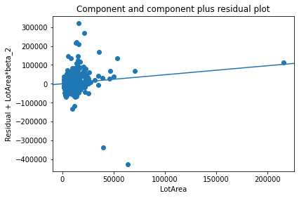

```python
fig = sm.graphics.plot_ccpr(model, 'LotArea')
fig.tight_layout(pad=1.0)
```

## Task 9

Frequently data is missing. Pick up 5 rows in the data set and delete the value for LotArea. Implement at least two approaches to fill in these values. Write down the corresponding formulas/model and give motivation for your approach. If you use standard routines, then check how exactly the data imputation is implemented. Note that for imputation you shall use the complete data set and not only the set of variables after feature selection.

```python
df_copy = df.copy()
missingData = np.random.choice(range(len(df)), 5)
df_copy.loc[missingData]
```

|  | Id | MSSubClass | MSZoning | LotFrontage | LotArea | Street | Alley | LotShape | LandContour | Utilities | LotConfig | LandSlope | Neighborhood | Condition1 | Condition2 | BldgType | HouseStyle | OverallQual | OverallCond | YearBuilt | YearRemodAdd | RoofStyle | RoofMatl | Exterior1st | Exterior2nd | MasVnrType | MasVnrArea | ExterQual | ExterCond | … |
| --- | --- | --- | --- | --- | --- | --- | --- | --- | --- | --- | --- | --- | --- | --- | --- | --- | --- | --- | --- | --- | --- | --- | --- | --- | --- | --- | --- | --- | --- | --- |
| 290 | 291 | 60 | RL | 120.0 | 15611 | Pave | NaN | Reg | Lvl | AllPub | Inside | Gtl | CollgCr | Norm | Norm | 1Fam | 2Story | 8 | 5 | 2006 | 2006 | Gable | CompShg | VinylSd | VinylSd | None | 0.0 | Gd | TA | … |
| 771 | 772 | 20 | RL | 67.0 | 8877 | Pave | NaN | Reg | Lvl | AllPub | Inside | Gtl | Edwards | Norm | Norm | 1Fam | 1Story | 4 | 5 | 1951 | 1951 | Gable | CompShg | Wd Sdng | Wd Sdng | None | 0.0 | TA | TA | … |
| 1193 | 1194 | 120 | RM | NaN | 4500 | Pave | NaN | Reg | Lvl | AllPub | FR2 | Gtl | Mitchel | Norm | Norm | TwnhsE | 1Story | 6 | 5 | 1999 | 1999 | Hip | CompShg | VinylSd | VinylSd | BrkFace | 425.0 | TA | TA | … |
| 1402 | 1403 | 20 | RL | 64.0 | 6762 | Pave | NaN | Reg | Lvl | AllPub | Inside | Gtl | CollgCr | Norm | Norm | 1Fam | 1Story | 7 | 5 | 2006 | 2006 | Gable | CompShg | VinylSd | VinylSd | None | 0.0 | Gd | TA | … |
| 630 | 631 | 70 | RM | 50.0 | 9000 | Pave | Grvl | Reg | Lvl | AllPub | Corner | Gtl | OldTown | Artery | Norm | 1Fam | 2Story | 5 | 6 | 1880 | 1991 | Gable | CompShg | VinylSd | VinylSd | None | 0.0 | TA | TA | … |

5 rows × 81 columns

```python
df_copy.loc[missingData, 'LotArea'] = np.mean(df_copy['LotArea'])
df_copy.loc[missingData]
```

|  | Id | MSSubClass | MSZoning | LotFrontage | LotArea | Street | Alley | LotShape | LandContour | Utilities | LotConfig | LandSlope | Neighborhood | Condition1 | Condition2 | BldgType | HouseStyle | OverallQual | OverallCond | YearBuilt | YearRemodAdd | RoofStyle | RoofMatl | Exterior1st | Exterior2nd | MasVnrType | MasVnrArea | ExterQual | ExterCond | … |
| --- | --- | --- | --- | --- | --- | --- | --- | --- | --- | --- | --- | --- | --- | --- | --- | --- | --- | --- | --- | --- | --- | --- | --- | --- | --- | --- | --- | --- | --- | --- |
| 290 | 291 | 60 | RL | 120.0 | 10516.828082 | Pave | NaN | Reg | Lvl | AllPub | Inside | Gtl | CollgCr | Norm | Norm | 1Fam | 2Story | 8 | 5 | 2006 | 2006 | Gable | CompShg | VinylSd | VinylSd | None | 0.0 | Gd | TA | … |
| 771 | 772 | 20 | RL | 67.0 | 10516.828082 | Pave | NaN | Reg | Lvl | AllPub | Inside | Gtl | Edwards | Norm | Norm | 1Fam | 1Story | 4 | 5 | 1951 | 1951 | Gable | CompShg | Wd Sdng | Wd Sdng | None | 0.0 | TA | TA | … |
| 1193 | 1194 | 120 | RM | NaN | 10516.828082 | Pave | NaN | Reg | Lvl | AllPub | FR2 | Gtl | Mitchel | Norm | Norm | TwnhsE | 1Story | 6 | 5 | 1999 | 1999 | Hip | CompShg | VinylSd | VinylSd | BrkFace | 425.0 | TA | TA | … |
| 1402 | 1403 | 20 | RL | 64.0 | 10516.828082 | Pave | NaN | Reg | Lvl | AllPub | Inside | Gtl | CollgCr | Norm | Norm | 1Fam | 1Story | 7 | 5 | 2006 | 2006 | Gable | CompShg | VinylSd | VinylSd | None | 0.0 | Gd | TA | … |
| 630 | 631 | 70 | RM | 50.0 | 10516.828082 | Pave | Grvl | Reg | Lvl | AllPub | Corner | Gtl | OldTown | Artery | Norm | 1Fam | 2Story | 5 | 6 | 1880 | 1991 | Gable | CompShg | VinylSd | VinylSd | None | 0.0 | TA | TA | … |

5 rows × 81 columns

```python
cols = np.array(df_copy.columns)
cols[cols == '1stFlrSF'] = 'FirstFlrSF'
cols[cols == '3SsnPorch'] = 'TreeSsnPorch'
cols[cols == '2ndFlrSF'] = 'SecondFlrSF'
df_copy.columns = cols
```

```python
# regression imputation
df_copy.loc[missingData, 'LotArea'] = np.nan
imp = smi.mice.MICEData(df_copy.select_dtypes(include=np.number))
fml = 'SalePrice ~ Id + MSSubClass + LotFrontage + LotArea + OverallQual + OverallCond + YearBuilt + YearRemodAdd + MasVnrArea + BsmtFinSF1 + BsmtFinSF2 + BsmtUnfSF + TotalBsmtSF + FirstFlrSF + SecondFlrSF + LowQualFinSF + GrLivArea + BsmtFullBath + BsmtHalfBath + FullBath + HalfBath + BedroomAbvGr + KitchenAbvGr + TotRmsAbvGrd + Fireplaces + GarageYrBlt + GarageCars + GarageArea + WoodDeckSF + OpenPorchSF + EnclosedPorch + TreeSsnPorch + ScreenPorch + PoolArea + MiscVal + MoSold + YrSold'
mice = smi.mice.MICE(fml, sm.OLS, imp)
results = mice.fit()
```

```python
imp.data.loc[missingData]
```

|  | Id | MSSubClass | LotFrontage | LotArea | OverallQual | OverallCond | YearBuilt | YearRemodAdd | MasVnrArea | BsmtFinSF1 | BsmtFinSF2 | BsmtUnfSF | TotalBsmtSF | FirstFlrSF | SecondFlrSF | LowQualFinSF | GrLivArea | BsmtFullBath | BsmtHalfBath | FullBath | HalfBath | BedroomAbvGr | KitchenAbvGr | TotRmsAbvGrd | Fireplaces | GarageYrBlt | GarageCars | GarageArea | WoodDeckSF | … |
| --- | --- | --- | --- | --- | --- | --- | --- | --- | --- | --- | --- | --- | --- | --- | --- | --- | --- | --- | --- | --- | --- | --- | --- | --- | --- | --- | --- | --- | --- | --- |
| 290 | 291 | 60 | 120.0 | 11988.0 | 8 | 5 | 2006 | 2006 | 0.0 | 0 | 0 | 1079 | 1079 | 1079 | 840 | 0 | 1919 | 0 | 0 | 2 | 1 | 3 | 1 | 8 | 1 | 2006.0 | 2 | 685 | 0 | … |
| 771 | 772 | 20 | 67.0 | 8414.0 | 4 | 5 | 1951 | 1951 | 0.0 | 836 | 0 | 0 | 836 | 1220 | 0 | 0 | 1220 | 0 | 0 | 1 | 0 | 2 | 1 | 6 | 0 | 1951.0 | 2 | 396 | 0 | … |
| 1193 | 1194 | 120 | 107.0 | 8923.0 | 6 | 5 | 1999 | 1999 | 425.0 | 883 | 0 | 341 | 1224 | 1224 | 0 | 0 | 1224 | 1 | 0 | 2 | 0 | 2 | 1 | 5 | 0 | 1999.0 | 2 | 402 | 0 | … |
| 1402 | 1403 | 20 | 64.0 | 5400.0 | 7 | 5 | 2006 | 2006 | 0.0 | 0 | 0 | 1286 | 1286 | 1294 | 0 | 0 | 1294 | 0 | 0 | 2 | 0 | 2 | 1 | 6 | 1 | 2006.0 | 2 | 662 | 168 | … |
| 630 | 631 | 70 | 50.0 | 7917.0 | 5 | 6 | 1880 | 1991 | 0.0 | 0 | 0 | 636 | 636 | 1089 | 661 | 0 | 1750 | 0 | 0 | 1 | 0 | 3 | 1 | 8 | 0 | 1937.0 | 1 | 240 | 0 | … |

*Mean imputation* is a method in which the missing value on a certain variable is replaced by the mean of the available cases. This method preserves samle mean of the feature, but reduces the sample variance.

*Regression imputation* fits a model on a variable with missing values. Predictions of this regression model are used to substitute the missing values in this variable. Relationships of features and $\texttt{SalePrice}$ (i.e. correlations, regression coefficients etc.) are preserved, since imputed values are based on regression models, while mean imputation or zero substitution doesn't have this advantage.

## Task 10

We consider now the model with $\texttt{SalePrice}$ and the model with $\texttt{log(SalePrice)}$. Run an appropriate test to decide which of the models is superior. Explain, the idea of the test and why you cannot make a similar decision using AIC/BIC, etc.

We need to use the $J$-test here to compare two models:

$y = SalePrice = \beta_0 + \sum \beta_i X_i$

$y^{log} = log(SalePrice) = \beta_0^{log} + \sum \beta_i^{log} X_i$

Then let's consider the next connection between the models:

$e^{\hat{y_{log}}} = z_i'\gamma + \delta \hat{y} + v_i$

The hypothesis:

$H_0: \delta=0$ (the log model is not supperior)

```python
X = sm.add_constant(df_new.drop('SalePrice', axis=1))
y = df_new['SalePrice']
y_log = np.log(y)

model = sm.OLS(y, X).fit()
model_log = sm.OLS(y_log, X).fit()
```

```python
# now let's model our hypothesis
X_test = sm.add_constant(model.predict(X)) # constant + beta * y
y_test = np.exp(model_log.predict(X)) # exp(y_log)
model_test = sm.OLS(y_test, X_test).fit(use_t=True)

print("p-value for rejecting H_0: ", model_test.pvalues.loc[0])
```

```
p-value for rejecting H_0:  0.0
```

We cannot use AIC/BIC here, because variables we compute have different measurement units (dollars vs log(dollars)).

## Task 11

We wish to assess the predictive ability of the estimated regression. Consider the full model and the model after features selection. Compare the two models using leave-one-out CV and 5-fold CV. Explain the idea of this technique with formulas and draw a conclusion about the predictive ability of the two models.

```python
X_full = sm.add_constant(df_numeric.drop('SalePrice', axis=1))
X_tuned = sm.add_constant(df_numeric[stepwise_result])
y = df_numeric['SalePrice']

print(X_full.shape, X_tuned.shape)
```

```
(1121, 38) (1121, 18)
```

```python
print("Leave-one-out cross-validation")
print("Full model RMSE: ", -np.mean(cross_val_score(LinearRegression(), X_full, y, cv=len(y), scoring='neg_root_mean_squared_error')))
print("Tuned model RMSE: ", -np.mean(cross_val_score(LinearRegression(), X_tuned, y, cv=len(y), scoring='neg_root_mean_squared_error')))
print("5-fold cross-validation")
print("Full model RMSE: ", -np.mean(cross_val_score(LinearRegression(), X_full, y, cv=5, scoring='neg_root_mean_squared_error')))
print("Tuned model RMSE: ", -np.mean(cross_val_score(LinearRegression(), X_tuned, y, cv=5, scoring='neg_root_mean_squared_error')))
```

```
Leave-one-out cross-validation
Full model RMSE:  23490.252773390497
Tuned model RMSE:  22833.457787290416
5-fold cross-validation
Full model RMSE:  41398.63225568809
Tuned model RMSE:  37709.869091668355
```

Let's explain the 5-fold cross-validation, for example.

1. Split the data such that 80% of the points go to the training set and 20% go to the test set.
2. Train the linear regression model using the training set
3. Compute the root mean squared error for the test set:

$RMSE = \sqrt{\frac{1}{K_{test}}\sum_{i=1}^{K_{test}} (y_i - \hat{y_i})^2}$

1. Do the cross validation 4 more times and compute the average RMSE.

From what we can see, the tuned model has less cross-validation error, thus, more explanatory power on the out-of-sample data.

# Problem 7

## Task 1

A nonlinear regression offers a flexible technique for modelling complex relationships. We wish to explain the $\texttt{SalePrice}$ by $\texttt{YearBuilt}$. Consider only the first 500 observations for this purpose.

```python
df_short = df[:500]
```

### Task 1a

Make a bivariate scatter plot and estimate an appropriate linear (!) model. Add the regression line to the plot.

Let's estimate the next model:

$y = \beta_0 + \beta_1 x + \beta_2 x^{2}$

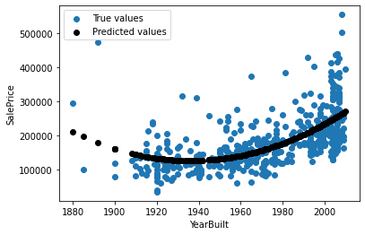

```python
X = sm.add_constant(df_short['YearBuilt'])
X['YearBuilt^2'] = np.power(df_short['YearBuilt'], 2)
y = df_short['SalePrice']

model_linear = sm.OLS(y, X).fit()

plt.scatter(df_short['YearBuilt'], df_short['SalePrice'], label='True values')
plt.scatter(df_short['YearBuilt'], model_linear.predict(X), label='Predicted values', color='black')
plt.xlabel('YearBuilt')
plt.ylabel('SalePrice')
plt.legend()
plt.show()
```

```python
print("The equation: y = {:.3} + {:.3}x + {:.3}x^2".format(model_linear.params['const'], model_linear.params['YearBuilt'], model_linear.params['YearBuilt^2']))
```

```
The equation: y = 1e+08 + -1.04e+05x + 26.8x^2
```

### Task 1b

Estimate now an appropriate nonlinear regression which might fit the data better.

Add the regression curve to the plot and compare (quantitatively) the fit with the fit of the linear model.

Let's estimate the next model:

$y = \beta_0 + \beta_1 x + \beta_2 x^{\beta_3}$

```python
def func(x, b0, b1, b2, b3):
  return b0 + b1 * x + b2 * np.power(x, b3)

def err_func(b, x, y):
  return func(x, *b) - y

x = np.array(df_short['YearBuilt'])
y = np.array(df_short['SalePrice'])
res = optimize.leastsq(err_func, x0=[1, 1, 1, 2], args=(x, y), maxfev=10000)
b0, b1, b2, b3 = res[0]
```

```python
print("The equation: y = {:.3} + {:.3}x + {:.3}x^{:.3}".format(b0, b1, b2, b3))
```

```
The equation: y = 8.57e+07 + -7.73e+04x + 1.35x^2.34
```

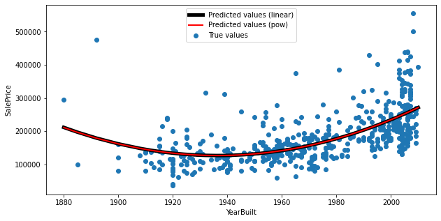

```python
y_true = df_short['SalePrice']
y_linear = model_linear.predict(X)
y_nonlinear = func(x, b0, b1, b2, b3)

order = np.argsort(df_short['YearBuilt'])
plt.figure(figsize=(10,5))
plt.scatter(df_short['YearBuilt'], df_short['SalePrice'], label='True values')
plt.plot(df_short['YearBuilt'][order], y_linear[order], label='Predicted values (linear)', color='black', linewidth=5)
plt.plot(df_short['YearBuilt'][order], y_nonlinear[order], label='Predicted values (pow)', color='red', linewidth=2)
plt.xlabel('YearBuilt')
plt.ylabel('SalePrice')
plt.legend()
plt.show()
```

```python
print("Linear model")
print("Sample mean: {:.3}".format(np.mean(y_linear - y_true)))
print("Sample standard deviation: {:.3}".format(np.std(y_linear - y_true)))
print("Nonlinear model")
print("Sample mean: {:.3}".format(np.mean(y_nonlinear - y_true)))
print("Sample standard deviation: {:.3}".format(np.std(y_nonlinear - y_true)))
```

```
Linear model
Sample mean: -9.8e-05
Sample standard deviation: 6.09e+04
Nonlinear model
Sample mean: -0.591
Sample standard deviation: 6.09e+04
```

$\begin{cases}y_{lm} = 1*10^8 -1.04*10^5x + 26.8x^2 \\ y_{nlm} = 8.57*10^7 -7.73*10^4x + 1.35x^2.34\end{cases}$

We can see that two models with identical loss were fitted, though the parameters are different.

### Task 1c

Explain in your own words, why all the classical tests and inferences are not directly applicable to the NLS estimators.

Linear regression: $y = \beta_0 + \beta_1X + u$

When doing linear regression, we assume that the noise $u \in N(0, \sigma^2)$. In the non-linear cases mean can be non-zero and the whole distribution is not normal. Let's give a look at the simple example from the previous task:

$y = \beta_0 + \beta_1x + \beta_2x^{\beta3 + u_1} + u_2$

Now the noise is both linear and exponential, and I don't know what tests might take that into account.

### Task 1d

What kind of problems might arise if we decide to fit a non-linear regression using all explanatory variables?

1. All our statistical methods (tests, correlation measures etc.) are not valid anymore.
2. *Modeling*: we don't know the true nonlinearity nature, so cannot create a correct model (even in a simple case of only $\texttt{YearBuilt}$ we are not sure which model to pick, what to do with 38 variables?).
3. *Modeling*: we need to provide a valid first guess, and problems are the same when creating a model.
4. *Mathematical*: when using iterative methods, we need to tune them not to stop at some local extremums (but high learning rates are bad, too).
5. *Overflows*: we might get infinities when computing matrix pseudoinverses in close-to-singular cases.
6. *Timing*: it might take some time for the model to converge (especially having small learning rates).

## Task 2

Next we model the relationship between $\texttt{SalePrice}$ and $\texttt{YearBuilt}$ using the non-parametric Nadaraya-Watson regression. Consider also only the first 500 observations for this purpose.

### Task 2a

An important calibration parameter of a nonparametric regression is the bandwidth. Explain what happens with the regression/the weights in the Nadaraya-Watson regression if the bandwidth is too high or too small.

Bandwidth too small: **undersmoothing**

The bandwidth captures very few points at one time, the density plot will look like a combination of individual peeks (one peek per each sample element).

Bandwidth too high: **oversmoothing**

The model changes too slowly to capture all changes, the density plot is far from the true histogram. This means the variance would be huge and we cannot capture anything specific about this distribution (it looks more or less homogenous).

### Task 2b

Fit a Nadaraya-Watson regression with Gaussian kernel and "optimal" bandwidth to this pair of variables. Check and explain how the "optimal bandwidth" is determined in your software. Compare the (in-sample) fit of the nonparametric regression and the nonlinear regression in the previous subproblem.

```python
# ckertype='gaussian' is the default
y_kde, _ = sm.nonparametric.KernelReg(df_short['SalePrice'], df_short['YearBuilt'], 'c').fit()
```

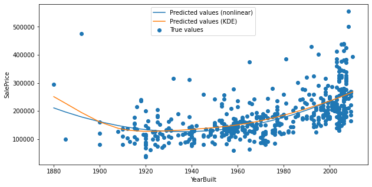

```python
order = np.argsort(df_short['YearBuilt'])
plt.figure(figsize=(10,5))
plt.scatter(df_short['YearBuilt'], df_short['SalePrice'], label='True values')
plt.plot(df_short['YearBuilt'][order], y_nonlinear[order], label='Predicted values (nonlinear)')
plt.plot(df_short['YearBuilt'][order], y_kde[order], label='Predicted values (KDE)')
plt.xlabel('YearBuilt')
plt.ylabel('SalePrice')
plt.legend()
plt.show()
```

```python
print("Nonlinear model")
print("Sample mean: {:.3}".format(np.mean(y_nonlinear - y_true)))
print("Sample standard deviation: {:.3}".format(np.std(y_nonlinear - y_true)))
print("Nonparametric model")
print("Sample mean: {:.3}".format(np.mean(y_kde - y_true)))
print("Sample standard deviation: {:.3}".format(np.std(y_kde - y_true)))
```

```
Nonlinear model
Sample mean: -0.591
Sample standard deviation: 6.09e+04
Nonparametric model
Sample mean: 3.78e+03
Sample standard deviation: 6.08e+04
```

Nonparametric model appears to be biased, but has smaller variance.

For bandwidth estimation, by default statsmodels use "least-squares cross-validation".